# Phân tích Thành phần chính cho Bộ dữ liệu Boston Housing

Vũ Ngọc Phương

2025-07-13

# 1. Giới thiệu

## 1.1. Tổng quan Bộ dữ liệu

Bộ dữ liệu Boston Housing chứa thông tin về các đặc điểm kinh tế, xã hội và môi trường của 506 khu dân cư tại thành phố Boston, Hoa Kỳ. Dữ liệu ban đầu được thu thập và công bố bởi Cơ quan Thống kê Nhà đất Boston và sau đó được sử dụng trong nhiều nghiên cứu học máy, bao gồm cả hồi quy tuyến tính và PCA.

### 1.1.1. Nguồn dữ liệu

[UCI Machine Learning Repository: Boston Housing Data Set](https://github.com/rupakc/UCI-Data-Analysis/tree/master/Boston%20Housing%20Dataset/Boston%20Housing)

### 1.1.2. Thông số cơ bản

- **Số mẫu:** 506 (khu dân cư)
- **Số đặc trưng:** 13 (biến định lượng và thứ tự)
- **Biến mục tiêu:** `MEDV` – Giá trị trung vị của nhà ở (nghìn USD)

### 1.1.3. Mô tả đặc trưng

13 đặc trưng được thu thập từ các nguồn thống kê và điều tra dân cư địa phương:

Bảng mô tả các biến trong bộ dữ liệu Boston Housing

| Biến | Loại biến | Mô tả |
| --- | --- | --- |
| CRIM | numeric | Tỷ lệ tội phạm bình quân đầu người theo khu vực |
| ZN | numeric | Tỷ lệ đất ở dành cho khu dân cư quy hoạch (>25,000 ft²) |
| INDUS | numeric | Tỷ lệ diện tích đất phi bán lẻ (non-retail) trên tổng diện tích đất theo khu - Tạm gọi là tỷ lệ diện tích đất công nghiệp |
| CHAS | binary | Giáp sông Charles (1 = có, 0 = không) |
| NOX | numeric | Nồng độ khí nitric oxit (phần triệu) - Tạm gọi là Độ ô nhiễm |
| RM | numeric | Số lượng phòng trung bình mỗi căn nhà |
| AGE | numeric | Tỷ lệ nhà thuộc sở hữu xây trước năm 1940 |
| DIS | numeric | Khoảng cách trọng số đến 5 trung tâm việc làm ở Boston |
| RAD | integer | Chỉ số khả năng tiếp cận đường cao tốc tới trung tâm |
| TAX | numeric | Thuế tài sản tính trên mỗi $10,000 giá trị bất động sản |
| PTRATIO | numeric | Tỷ lệ học sinh trên giáo viên theo khu vực |
| B | numeric | Chỉ số liên quan đến tỷ lệ người da màu trong khu vực |
| LSTAT | numeric | Tỷ lệ dân số thuộc tầng lớp thu nhập thấp |
| MEDV | numeric | Giá trị trung vị của nhà (nghìn USD) — biến mục tiêu |

## 1.2. Mục tiêu

- Kiểm tra và xử lý dữ liệu sao cho không bị khuyết, không có extreme outlier để tránh làm lệch phân tích thành phần chính
- Giảm chiều dữ liệu từ 13 biến xuống còn 2-4 biến thành phần chính
- Giữ lại >70% phương sai dữ liệu
- Chia biến mục tiêu thành các nhóm giá nhà thấp, vừa và cao để phân tích
- Trực quan hóa phân cụm tự nhiên giữa các nhóm giá nhà
- Xác định các đặc trưng quan trọng nhất trong chẩn đoán nhóm giá nhà

# 2. Chuẩn bị dữ liệu và thư viện cần thiết

```r
data = read.table("housing.data", header = FALSE)
colnames(data) = c("CRIM", "ZN", "INDUS", "CHAS", "NOX", "RM", "AGE", "DIS", "RAD", "TAX", "PTRATIO", "B", "LSTAT", "MEDV")

# Một vài mẫu dữ liệu
kable(head(data), format = "html", caption = "Bảng dữ liệu mẫu") %>%
  kable_styling(bootstrap_options = c("striped", "hover", "condensed"))
```

Bảng dữ liệu mẫu

| CRIM | ZN | INDUS | CHAS | NOX | RM | AGE | DIS | RAD | TAX | PTRATIO | B | LSTAT | MEDV |
| --- | --- | --- | --- | --- | --- | --- | --- | --- | --- | --- | --- | --- | --- |
| 0.00632 | 18 | 2.31 | 0 | 0.538 | 6.575 | 65.2 | 4.0900 | 1 | 296 | 15.3 | 396.90 | 4.98 | 24.0 |
| 0.02731 | 0 | 7.07 | 0 | 0.469 | 6.421 | 78.9 | 4.9671 | 2 | 242 | 17.8 | 396.90 | 9.14 | 21.6 |
| 0.02729 | 0 | 7.07 | 0 | 0.469 | 7.185 | 61.1 | 4.9671 | 2 | 242 | 17.8 | 392.83 | 4.03 | 34.7 |
| 0.03237 | 0 | 2.18 | 0 | 0.458 | 6.998 | 45.8 | 6.0622 | 3 | 222 | 18.7 | 394.63 | 2.94 | 33.4 |
| 0.06905 | 0 | 2.18 | 0 | 0.458 | 7.147 | 54.2 | 6.0622 | 3 | 222 | 18.7 | 396.90 | 5.33 | 36.2 |
| 0.02985 | 0 | 2.18 | 0 | 0.458 | 6.430 | 58.7 | 6.0622 | 3 | 222 | 18.7 | 394.12 | 5.21 | 28.7 |

# 3. Tìm hiểu dữ liệu

## 3.1. Phân tích tổng quan

```r
# Số quan trắc và số chiều của dữ liệu
dim(data)
```

```
## [1] 506  14
```

```r
# Thống kê mô tả cơ bản của dữ liệu
summary(data)
```

```
##       CRIM                ZN             INDUS            CHAS
##  Min.   : 0.00632   Min.   :  0.00   Min.   : 0.46   Min.   :0.00000
##  1st Qu.: 0.08205   1st Qu.:  0.00   1st Qu.: 5.19   1st Qu.:0.00000
##  Median : 0.25651   Median :  0.00   Median : 9.69   Median :0.00000
##  Mean   : 3.61352   Mean   : 11.36   Mean   :11.14   Mean   :0.06917
##  3rd Qu.: 3.67708   3rd Qu.: 12.50   3rd Qu.:18.10   3rd Qu.:0.00000
##  Max.   :88.97620   Max.   :100.00   Max.   :27.74   Max.   :1.00000
##       NOX               RM             AGE              DIS
##  Min.   :0.3850   Min.   :3.561   Min.   :  2.90   Min.   : 1.130
##  1st Qu.:0.4490   1st Qu.:5.886   1st Qu.: 45.02   1st Qu.: 2.100
##  Median :0.5380   Median :6.208   Median : 77.50   Median : 3.207
##  Mean   :0.5547   Mean   :6.285   Mean   : 68.57   Mean   : 3.795
##  3rd Qu.:0.6240   3rd Qu.:6.623   3rd Qu.: 94.08   3rd Qu.: 5.188
##  Max.   :0.8710   Max.   :8.780   Max.   :100.00   Max.   :12.127
##       RAD              TAX           PTRATIO            B
##  Min.   : 1.000   Min.   :187.0   Min.   :12.60   Min.   :  0.32
##  1st Qu.: 4.000   1st Qu.:279.0   1st Qu.:17.40   1st Qu.:375.38
##  Median : 5.000   Median :330.0   Median :19.05   Median :391.44
##  Mean   : 9.549   Mean   :408.2   Mean   :18.46   Mean   :356.67
##  3rd Qu.:24.000   3rd Qu.:666.0   3rd Qu.:20.20   3rd Qu.:396.23
##  Max.   :24.000   Max.   :711.0   Max.   :22.00   Max.   :396.90
##      LSTAT            MEDV
##  Min.   : 1.73   Min.   : 5.00
##  1st Qu.: 6.95   1st Qu.:17.02
##  Median :11.36   Median :21.20
##  Mean   :12.65   Mean   :22.53
##  3rd Qu.:16.95   3rd Qu.:25.00
##  Max.   :37.97   Max.   :50.00
```

```r
# Kiểm tra phân bố lớp CHAS
chas_distribution = table(data$CHAS)
print(chas_distribution)
```

```
##
##   0   1
## 471  35
```

Trong bước này, ta sẽ tạm loại bỏ hai biến `CHAS` và `MEDV` khỏi bộ dữ liệu vì các lý do sau:

- **Biến `CHAS`**: Đây là một biến nhị phân, đại diện cho việc một khu vực có giáp sông Charles River hay không. Tuy nhiên, biến này có sự mất cân bằng nghiêm trọng (đa số là giá trị 0), điều này có thể gây sai lệch khi:
  - Tính toán phương sai trong phân tích thành phần chính (PCA).
  - Tính khoảng cách trong các phương pháp phát hiện ngoại lai (outlier detection), đặc biệt là khi sử dụng khoảng cách Euclidean.
- **Biến `MEDV`**: Là biến mục tiêu đại diện cho giá trị trung vị của nhà ở (đơn vị: nghìn USD). Việc giữ lại biến này trong quá trình giảm chiều (PCA, t-SNE, …) sẽ dẫn đến rò rỉ thông tin (data leakage), làm sai lệch kết quả phân tích hoặc ảnh hưởng đến hiệu quả của các mô hình dự đoán. Do đó, `MEDV` cần được loại trừ để đảm bảo tính khách quan khi đánh giá mối liên hệ giữa các thành phần chính và các biến đầu vào.

==> Ta sẽ dùng chúng sau khi thực hiện PCA.

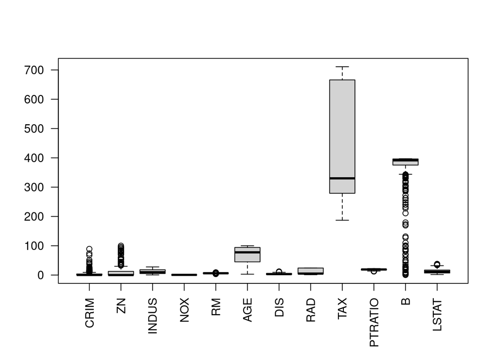

```r
data_housing = data %>% select(-CHAS, -MEDV)

# Đồ thị Boxplot
boxplot(data_housing, las = 2)
```

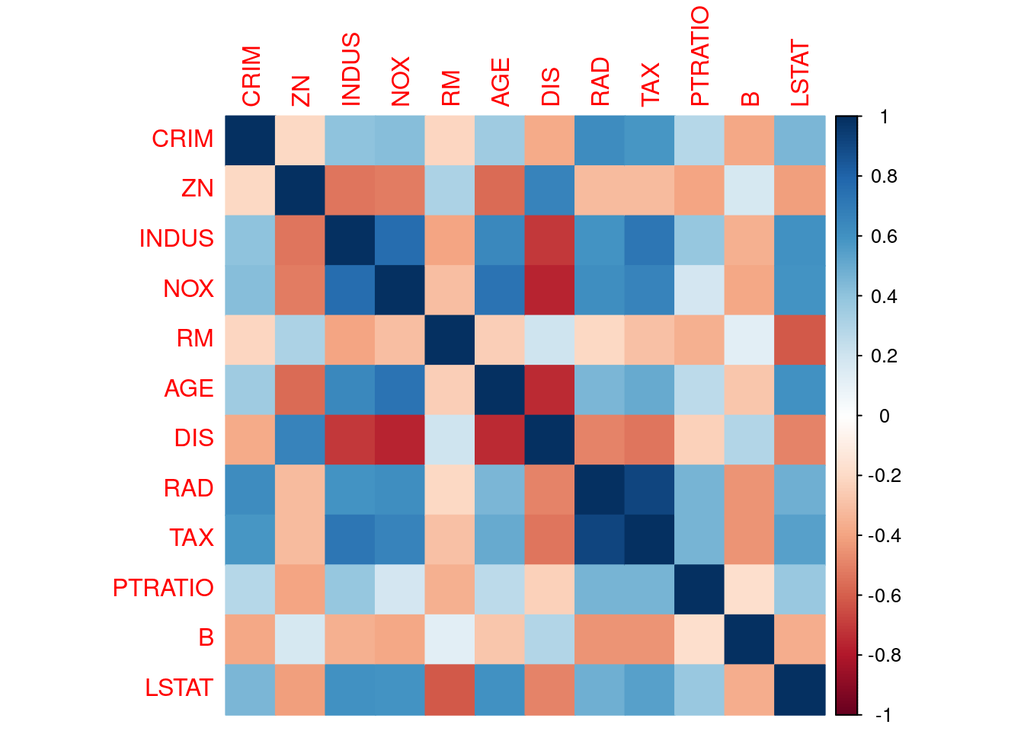

```r
corrplot(cor(data_housing), method = "color")
```

**Nhận xét:**

- Bộ dữ liệu có 506 quan trắc với 14 biến, trong đó có biến `MEDV` là biến mục tiêu.
- Ta tạm loại bỏ hai biến `CHAS` và `MEDV` để phân tích PCA.
- Từ thống kê mô tả và boxplot, ta thấy các biến thuộc nhiều khoảng giá trị khác nhau (có những cách biệt rất lớn), đồng thời tiềm năng tồn tại nhiều giá trị ngoại lai. Điều này sẽ ảnh hưởng rất lớn tới phương sai của dữ liệu khi phân tích thành phần chính nếu không được xử lý (vì PCA tính toán dựa trên phương sai).
- Từ biểu đồ heatmap, ta thấy một vài biến có tương quan cao như:
  - `TAX` (Thuế bất động sản) và `RAD` (Khả năng tiếp cận cao tốc) có tương quan dương cao. Điều này hợp lý với thực tế vì các khu vực càng gần nhiều tuyến đường cao tốc xuyên tâm (`RAD` cao) thường có hạ tầng giao thông phát triển, dễ tiếp cận trung tâm hơn và có mức đầu tư lớn, dẫn đến thuế bất động sản (`TAX`) cao hơn để bù chi phí hạ tầng.
  - `DIS` (Khoảng cách tới trung tâm làm việc) và `AGE` (Tỉ lệ nhà cổ) có tương quan âm cao. Điều này cho thấy càng xa trung tâm (`DIS` cao) thì nhà càng mới (`AGE` thấp), như vậy quá trình đô thị hóa lan dần từ trung tâm ra ngoại ô.
  - `DIS` (Khoảng cách tới trung tâm làm việc) và `NOX` (Độ ô nhiễm) có tương quan âm cao. Điều này cũng sát với thực tế khi các khu vực xa trung tâm (thường là khu dân cư hoặc vùng ven đô) sẽ có ít khí thải NO hơn vì mật độ xe cộ, khí thải thường thấp hơn.

  Các biến tương quan cao sẽ gây ra đa cộng tuyến khi sử dụng mô hình Hồi quy Tuyến tính và PCA là một phương pháp cực kỳ hiệu quả để xử lý vấn đề này.

**Cần xử lý:**

- Kiểm tra sâu hơn các giá trị ngoại lai
- Chuẩn hóa các biến
- Kiểm tra có tồn tại dữ liệu khuyết không

## 3.2. Kiểm tra dữ liệu khuyết

```r
# Kiểm tra số lượng giá trị khuyết theo từng biến:
colSums(is.na(data))
```

```
##    CRIM      ZN   INDUS    CHAS     NOX      RM     AGE     DIS     RAD     TAX
##       0       0       0       0       0       0       0       0       0       0
## PTRATIO       B   LSTAT    MEDV
##       0       0       0       0
```

Dữ liệu không bị khuyết bất kỳ giá trị nào nên ta sẽ không cần phải xử lý dữ liệu khuyết.

## 3.3. Kiểm tra giá trị ngoại lai

```r
# Gắn rowid để theo dõi dòng
data_with_id = data %>%
  mutate(rowid = row_number())

# Kiểm tra outlier
# Xác định outlier đơn biến
univ_outliers = list()

for (i in names(data_housing)) {
  (out = data_with_id %>%
    identify_outliers(all_of(i)) %>%
    filter(is.extreme == TRUE) %>%
    select(rowid))

  if (nrow(out) > 0) {
    univ_outliers[[i]] = out
  }
}

# Lưu lại các id là extreme outlier (1 chiều)
univ_extremes = bind_rows(univ_outliers) %>% distinct()

# In ra các quan trắc là extreme outlier (1 chiều)
outlier_rows = data_with_id %>%
  filter(rowid %in% univ_extremes$rowid)

# Số lượng extreme outlier 1 chiều
dim(outlier_rows)
```

```
## [1] 123  15
```

```r
# Outlier đa biến
multi_extremes = data_with_id %>%
  select(-CHAS, -MEDV)  %>%
  mahalanobis_distance() %>%
  filter(is.outlier == TRUE) %>%
  select(rowid)

# In ra các quan trắc là extreme outlier (nhiều chiều)
outlier_rows = data_with_id %>%
  filter(rowid %in% multi_extremes$rowid)

# Số lượng extreme outlier nhiều chiều
dim(outlier_rows)
```

```
## [1] 14 15
```

```r
# Hợp nhất các quan trắc là extreme outlier (cả nhiều và 1 chiều)
extreme_ids = bind_rows(univ_extremes, multi_extremes) %>% distinct()

# Trích toàn bộ dòng extreme
all_extremes = data_with_id %>%
  semi_join(extreme_ids, by = "rowid") %>%
  select(-rowid)

# Số lượng extreme outlier tổng cộng
dim(all_extremes)
```

```
## [1] 129  14
```

**Nhận xét:**

- Sau khi kiểm tra ta thấy có tổng cộng 129 quan trắc là ngoại lai cực đoan - extreme outlier. Các quan trắc này chiếm khoảng 25.49% lượng dữ liệu và có thể làm lệch các phân tích sau này của ta nên dù mất khá nhiều quan trắc nhưng ta vẫn sẽ loại bỏ chúng.

```r
# Loại bỏ các extreme outlier
data_clean = data_with_id %>%
  anti_join(extreme_ids, by = "rowid") %>%
  select(-rowid)

data_housing_clean = data_clean %>% select(-CHAS, -MEDV)

# Số chiều của dữ liệu sau khi loại bỏ
dim(data_clean)
```

```
## [1] 377  14
```

## 3.4. Chuẩn hóa dữ liệu

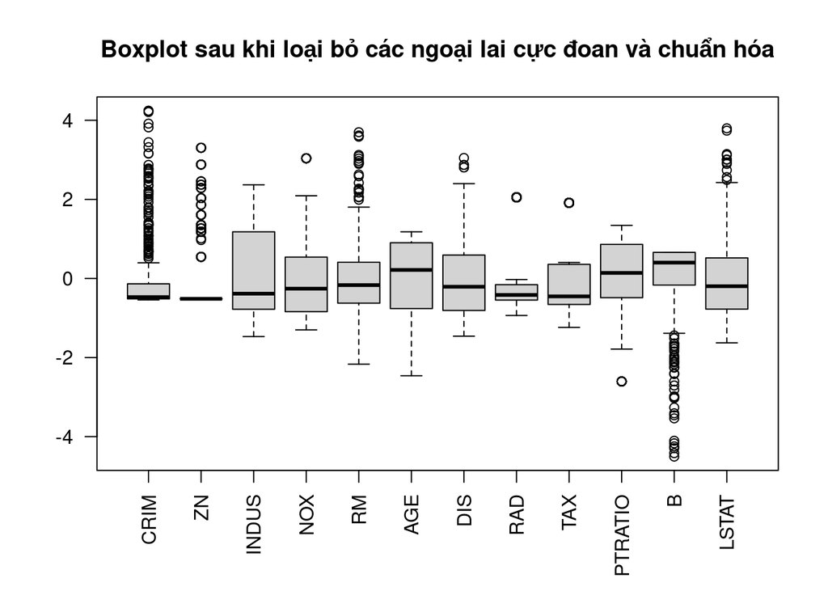

```r
# Chuẩn hóa
data_scaled = scale(data_housing_clean)
data_scaled = as.data.frame(data_scaled)
boxplot(data_scaled,
        las = 2,
        main = "Boxplot sau khi loại bỏ các ngoại lai cực đoan và chuẩn hóa")
```

**Nhận xét:**

## 3.5. Tạo biến mục tiêu mới

Bởi vì biến mục tiêu `MEDV` của bộ dữ liệu là biến số liên tục - phù hợp với bài toán hồi quy. Tuy nhiên, ta muốn phân tích bộ dữ liệu bằng phân tích thành phần chính và tìm hiểu thành phần chính/biến đặc trưng nào có thể chẩn đoán tốt giá nhà nên ta sẽ tạo biến mới là biến phân loại `MEDV_cat` dựa trên `MEDV`. Biến phân loại sẽ giúp ta dễ trực quan hóa để phân tích các xu hướng, ý nghĩa hơn.

*Lưu ý: Cách chia mỗi nhóm tùy thuộc vào mục đích và cách thức phân tích, nghiên cứu. Trong trường hợp này, ta sử dụng phương pháp chia theo tứ phân vị của biến `MEDV`:

- Nhóm giá thấp - `low`: MEDV nhỏ hơn Q1 (tứ phân vị thứ nhất)
- Nhóm giá trung bình - `medium`: MEDV nằm giữa Q1 và Q3
- Nhóm giá cao - `high`: MEDV lớn hơn Q3 (tứ phân vị thứ ba)

```r
# Tính các tứ phân vị
Q1 = quantile(data_clean$MEDV, 0.25)
Q3 = quantile(data_clean$MEDV, 0.75)

# Tạo biến phân loại MEDV_cat
data_clean$MEDV_cat <- cut(
  data_clean$MEDV,
  breaks = c(-Inf, Q1, Q3, Inf),
  labels = c("low", "medium", "high"),
  right = TRUE,  # Bao gồm giới hạn bên phải (<=)
  include.lowest = TRUE
)

# Kiểm tra phân bố lớp MEDV_cat
mdev_cat_distribution = table(data_clean$MEDV_cat)
print(mdev_cat_distribution)
```

```
##
##    low medium   high
##     96    187     94
```

# 4. Phân tích thành phần chính

## 4.1. Số lượng thành phần chính giữ lại

```r
# Xây dựng các thành phần chính
pca = princomp(data_scaled)
summary(pca)
```

```
## Importance of components:
##                           Comp.1    Comp.2    Comp.3     Comp.4     Comp.5
## Standard deviation     2.3495981 1.2171212 1.1905562 0.99525927 0.89718612
## Proportion of Variance 0.4612745 0.1237770 0.1184328 0.08276462 0.06725698
## Cumulative Proportion  0.4612745 0.5850515 0.7034843 0.78624890 0.85350588
##                            Comp.6     Comp.7     Comp.8    Comp.9    Comp.10
## Standard deviation     0.68835319 0.63430662 0.52608030 0.4583471 0.42659888
## Proportion of Variance 0.03959086 0.03361791 0.02312471 0.0175534 0.01520588
## Cumulative Proportion  0.89309674 0.92671465 0.94983937 0.9673928 0.98259865
##                           Comp.11     Comp.12
## Standard deviation     0.38485072 0.245259507
## Proportion of Variance 0.01237533 0.005026017
## Cumulative Proportion  0.99497398 1.000000000
```

```r
# Các trị riêng của từng thành phần chính
(eigenvalues = (pca$sdev)^2)
```

```
##     Comp.1     Comp.2     Comp.3     Comp.4     Comp.5     Comp.6     Comp.7
## 5.52061121 1.48138401 1.41742412 0.99054101 0.80494294 0.47383012 0.40234489
##     Comp.8     Comp.9    Comp.10    Comp.11    Comp.12
## 0.27676049 0.21008206 0.18198661 0.14811007 0.06015223
```

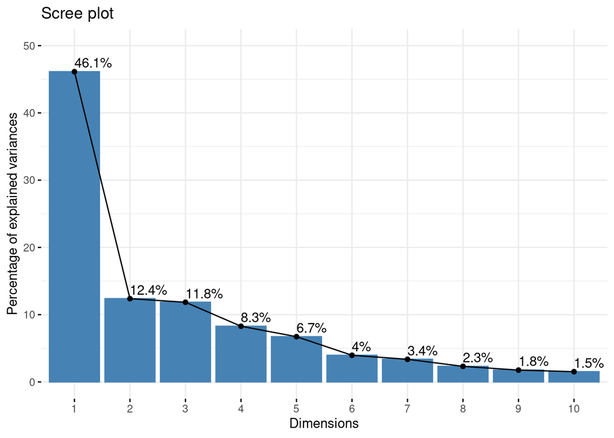

```r
# Scree plot
factoextra::fviz_eig(pca, addlabels = TRUE, ylim = c(0, 50))
```

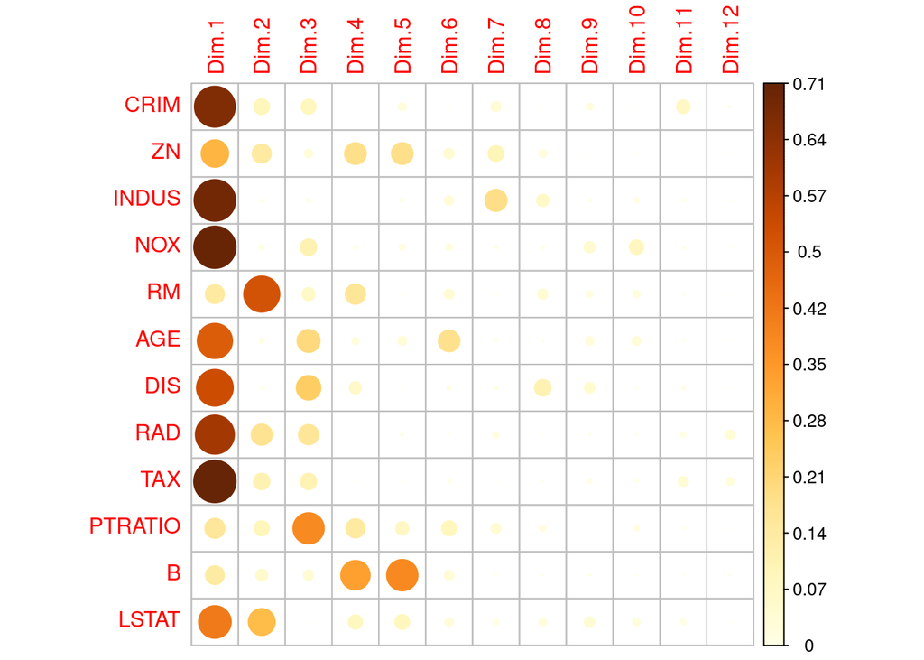

```r
var = factoextra::get_pca_var(pca)
corrplot::corrplot(var$cos2, is.corr=FALSE)
```

**Nhận xét:**

Ta sẽ phân tích cần phải giữ lại bao nhiêu thành phần chính để giữ lại phần lớn lượng dữ liệu theo các tiêu chuẩn:

- Tỉ lệ phương sai tích lũy: Nếu đặt mốc chấp nhận được là 70% thì ta cần phải giữ lại 3 thành phần chính đầu tiên (giải thích được 70.35% phương sai suy rộng).
- Kaiser: Ta giữ lại 3 thành phần chính đầu tiên vì chỉ có chúng là có trị riêng > 1.
- Phương pháp khuỷu tay với Scree plot: Khuỷu tay nằm ở thành phần chính thứ 2, nên ta chỉ giữ lại 2 thành phần chính đầu tiên. Tuy nhiên, với cách chọn này, ta chỉ giữ lại được 58.5% phương sai suy rộng - là gần một nửa lượng thông tin ban đầu của dữ liệu.
- Đầy đủ thông tin về các biến: Nếu ta muốn phân tích hoặc có thêm nhiều thông tin từ biến B, ta có thể cân nhắc giữ lại 4-5 thành phần chính đầu tiên vì chỉ có thành phần chính thứ 4 và thứ 5 là giải thích tốt cho biến B.

==> Ta chọn theo tỉ lệ phương sai tích lũy, giữ lại 3 thành phần chính đầu tiên cho các phân tích sau.